# Cours CRC - partie 2

Hoguin

2021

## Calcul matriciel d’un CRC

- On suppose que le CRC est calculé à partir d’une matrice **génératrice**.
- Par exemple prenons :
  $$G = \begin{pmatrix} 0 & 1 \\ 1 & 1 \end{pmatrix}$$
- Prenons le message suivant $M=\begin{pmatrix} 1 & 0\end{pmatrix}$ (2 bits)
- Comment utiliser la matrice $G$ pour calculer le CRC ?
  - On fait le calcul du produit matriciel $M \times G$ en booléen
  - en ramplaçant l’addition par un $\oplus$
  - en remplaçant la multiplication par un **ET** logique
  - cela donne :
    $$M \times G=\begin{pmatrix}0 & 1 \end{pmatrix}$$
- conclusion le CRC du message $M=\begin{pmatrix} 1 & 0\end{pmatrix}$ est $\begin{pmatrix}0 & 1 \end{pmatrix}$

Petite vidéo pour le calcul matriciel si vous avez oublié :

matrice

## Exercices

### Exercice 1

Démontrer qu’un message constitué que de $0$ (zéro) possède un CRC constitué que de $0$ également

### Exercice 2

Si ma matrice $G$ est de dimension $(5,3)$ :

- Quelle est la longeur du CRC ?
- Quel mot puis-je utiliser ? (longueur) ?

### Exercice 3

Déterminer l’ensemble des cRC pour tous les mots de $3$ bits en prenant la matrice génératrice suivante : $G = \begin{pmatrix} 0 & 1 \\ 1 & 0 \\ 1 & 1\end{pmatrix}$

### Exercice 4

Déterminer la matrice génératrice de ce lanagage (mot de 5 bits + CRC de 3 bits)

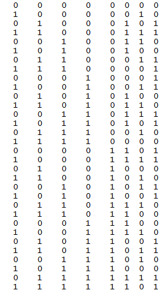

### Exercice 5

Ecrire un programme (dans le langage que vous souhaitez) qui permet de calculer le CRC (méthode matriciel) en prenant comme point de départ une matrice génératrice et un mot.